# Active Campaign Analysis

Siddharth Raina

*Loading required libraries*

*Reading required data file*

```r
head(data)
```

```
## # A tibble: 6 × 2
##      X1     x
##   <int> <dbl>
## 1     1    -7
## 2     2     1
## 3     3     6
## 4     4    -4
## 5     5    -2
## 6     6     0
```

```r
dim(data)
```

```
## [1] 526116      2
```

The time series has no date variable associated with it and 526116 instances.

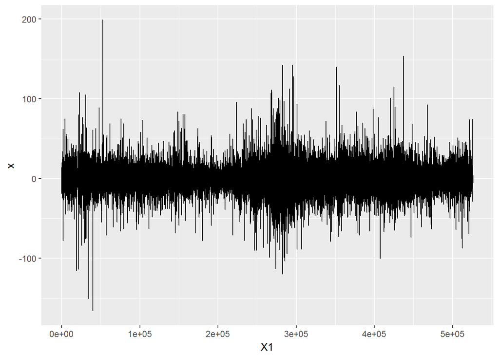

```r
ts <- ts(data$x)
ggplot(data,aes(x=X1,y=x))+geom_line()
```

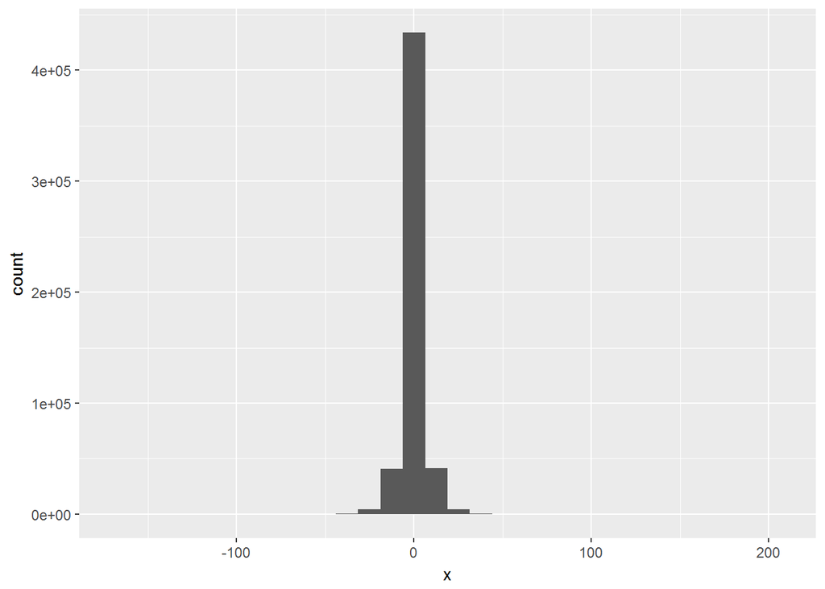

```r
ggplot(data,aes(x))+geom_histogram()
```

From the initial looks, the time series has no distinct patterns and the data seems to be heavily distributed around zero with long tails on each side.

```r
summary(ts)
```

```
##       Min.    1st Qu.     Median       Mean    3rd Qu.       Max.
## -166.00000   -2.00000    0.00000    0.03415    2.00000  199.00000
```

The IQR of 4 shows a very dense area near zero, but there still are huge outliers, if we are comparing these values to the spread of the rest of the data.

Let us try to look at a box plot.

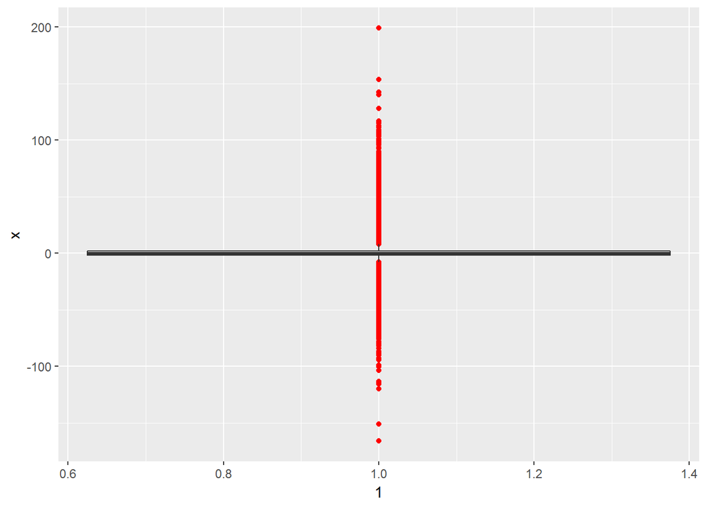

```r
ggplot(data,aes(y=x,x=1))+geom_boxplot(outlier.colour  = "red")
```

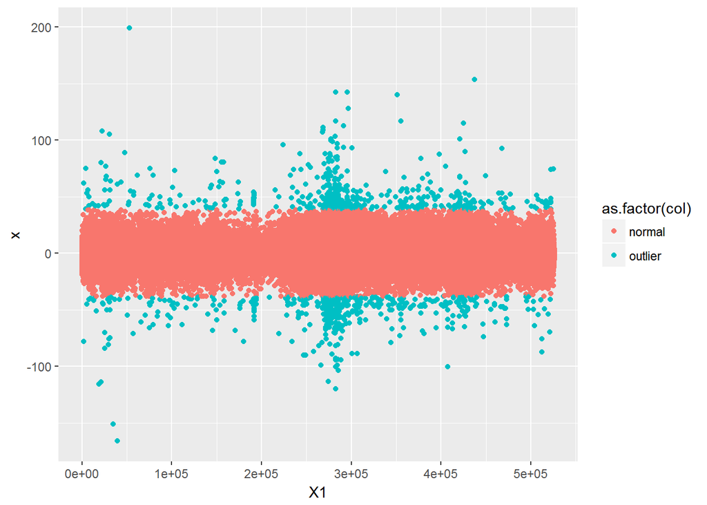

```r
col <- ifelse(ts<quantile(ts,0.001),"outlier",ifelse(ts>quantile(ts,0.999),"outlier","normal"))
ggplot(data,aes(x=X1,y=x,color=as.factor(col)))+geom_point()
```

They seem to be all over the sequence

I will try to smooth the series by calculating window statistics with a window size of apx. 2% of entire series. Checking for moving window statistics

```r
moving_avg <- rollapply(data=ts,width=10000,FUN=mean,align="right")
moving_median <- rollapply(data=ts,width=10000,FUN=median,align="right")
moving_variance <- rollapply(data=ts,width=10000,FUN=var,align="right")
```

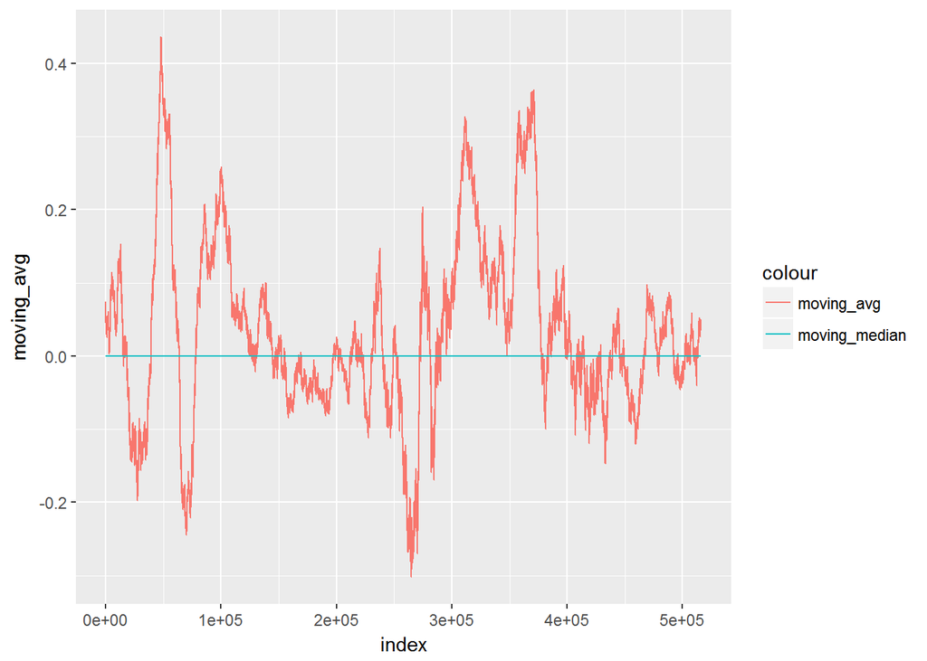

```r
mov <- data.frame(
                "moving_avg" = moving_avg,
                "moving_median" = moving_median,
                "index" = seq(1:length(moving_avg))
                )

ggplot(mov,aes(index))+
  geom_line(aes(y=moving_avg,col="moving_avg"))+
  geom_line(aes(y=moving_median,col="moving_median"))
```

The graph clearly shows how the moving average is affected by the outliers and the population density is still near the zero value as shown by the moving median.

Also there seems to be no clear trend here.

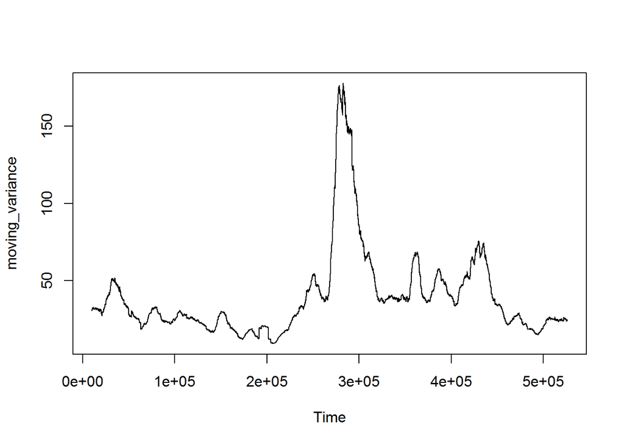

```r
plot.ts(moving_variance)
```

This shows that the average and variance of the time series is very volatile and changing with time.

Let us perform a Dickey-Fuller Test to check if the series is stationary or not

```r
adf.test(ts,alternative = "stationary")
```

```
##
##  Augmented Dickey-Fuller Test
##
## data:  ts
## Dickey-Fuller = -79.896, Lag order = 80, p-value = 0.01
## alternative hypothesis: stationary
```

The null hypothesis of the series being non-stationary can thus be rejected. Looks like there is no need of differencing

Checking for auto correlations

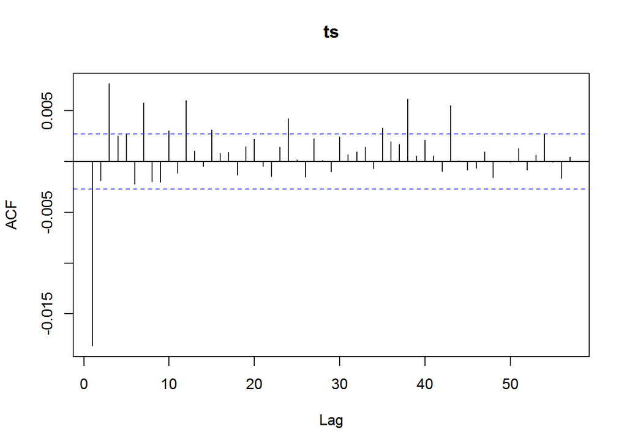

```r
Acf(ts)
```

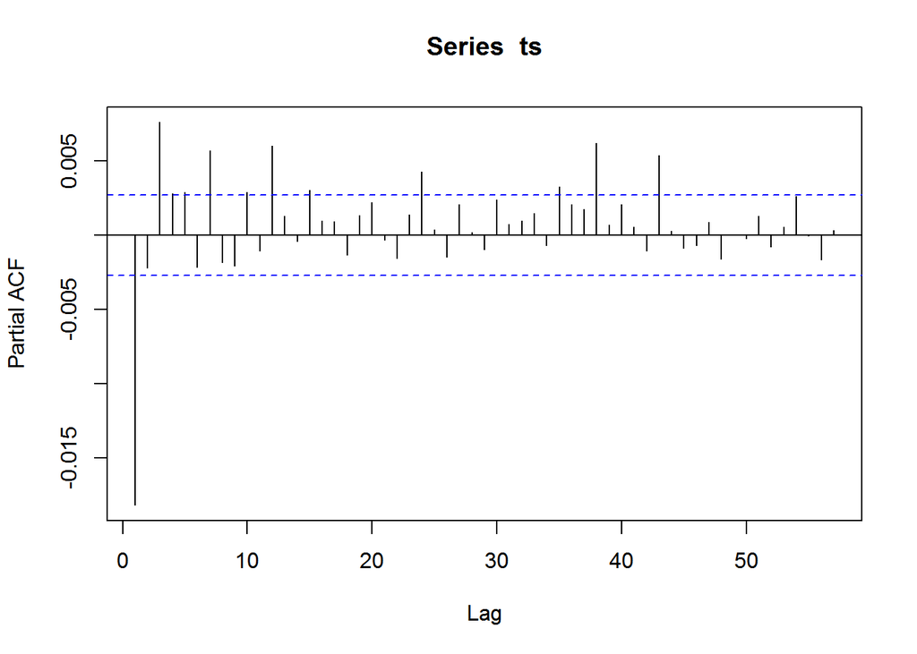

```r
Pacf(ts)
```

The scale of y axis shows that there is very little (around 0.015) autocorrelation present in the series.

Let us try to fit an arma(p,q) model to this series. Using BIC minimizing strategy to include some penalty for complex models. To reduce overfitting.

```r
final.bic <- Inf
final.order <- c(0,0,0)
for(p in 1:4) for(q in 1:4)
{
  arimafit <- arima(ts,order=c(p,0,q))
  current.bic <- BIC(arimafit)
  if(current.bic < final.bic){
    final.bic <- current.bic
    final.order <- c(p,0,q)
    final.arima <- arima(ts,final.order)
  }

}
```

```r
final.arima
```

```
##
## Call:
## arima(x = ts, order = final.order)
##
## Coefficients:
##           ar1      ma1      ma2     ma3  intercept
##       -0.0091  -0.0091  -0.0020  0.0077     0.0341
## s.e.   0.4498   0.4498   0.0083  0.0023     0.0085
##
## sigma^2 estimated as 39.24:  log likelihood = -1711894,  aic = 3423800
```

```r
mean(final.arima$residuals)
```

```
## [1] -1.131781e-07
```

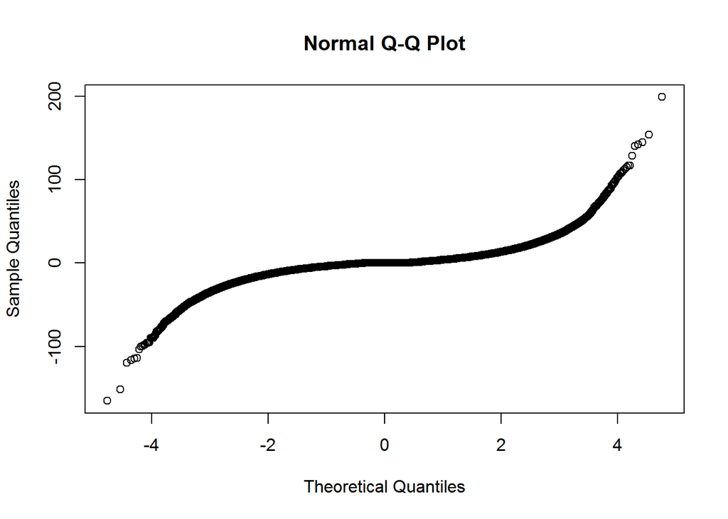

```r
qqnorm(y=residuals(final.arima))
```

Residuals show a mean near 0 but are not normally distributed around it.

```r
Box.test(final.arima$res,type="Ljung-Box")
```

```
##
##  Box-Ljung test
##
## data:  final.arima$res
## X-squared = 6.3712e-05, df = 1, p-value = 0.9936
```

Checking for autocorrelation in residuals

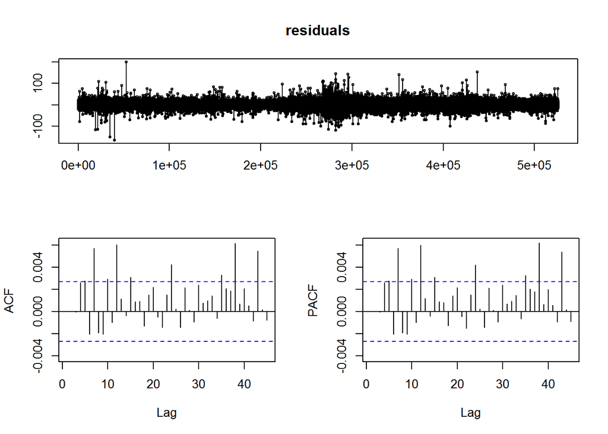

```r
residuals <- residuals(final.arima)
tsdisplay(residuals,lag.max=45)
```

The residuals still show some heteroskedasticity.

Checking for autocorrelation in squared residuals - Checking for Heteroskedasticity

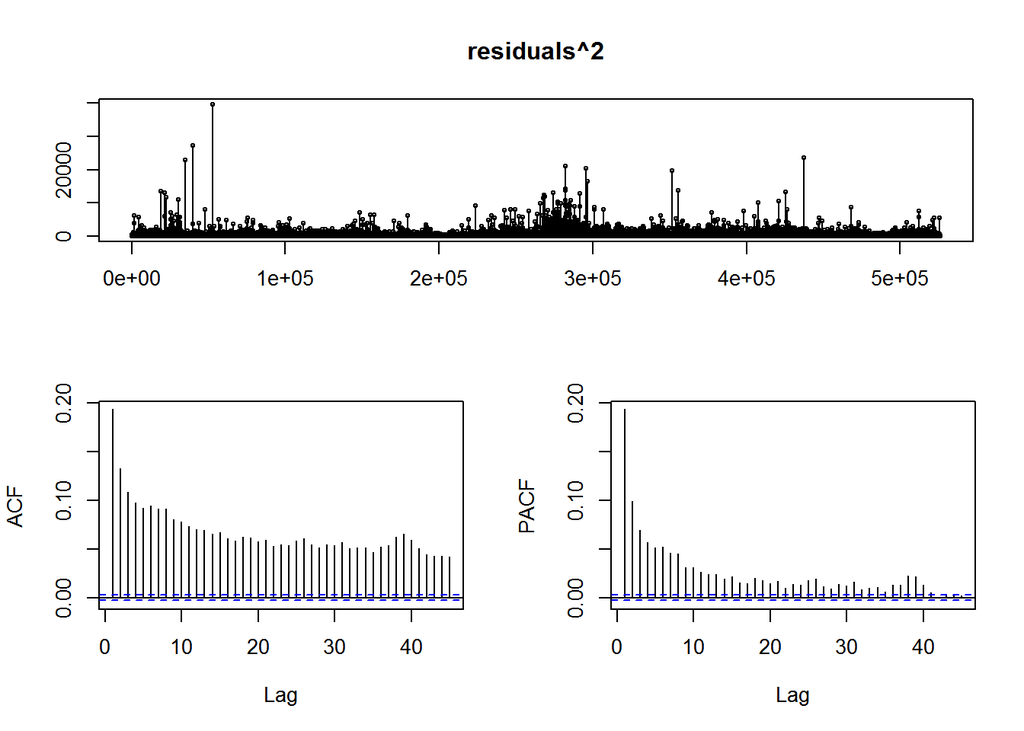

```r
tsdisplay(residuals^2,lag.max=45)
```

Squared residuals definitely show some pattern based on the Acf and Pacf plots.

Checking for ARCH effects.

```r
ArchTest(ts)
```

```
##
##  ARCH LM-test; Null hypothesis: no ARCH effects
##
## data:  ts
## Chi-squared = 35128, df = 12, p-value < 2.2e-16
```

Based on the p-value we can reject the null hypothesis of no ARCH effects. In other words there are significant ARCH effects in the sequence.

This heteroskedasticity make it really hard to make point estimates for the time sequence data.

Next let us try to fit a GARCH (Generalized Autoregressive Conditional Heteroskedasticity) model to this data in order to fit the volaitility in this data.

Fitting a GARCH model

```r
fit <- garchFit(train~arma(1,3)+garch(1,1),trace = F,cond.dist = "std",include.mean=TRUE)
```

```r
summary(fit)
```

[output not shown]

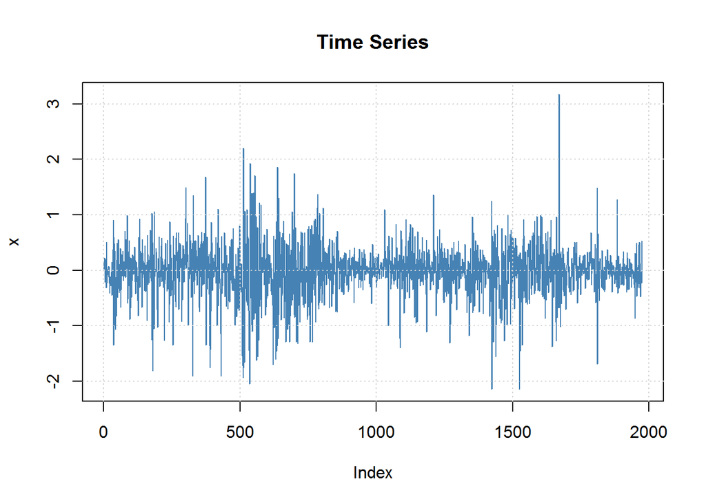

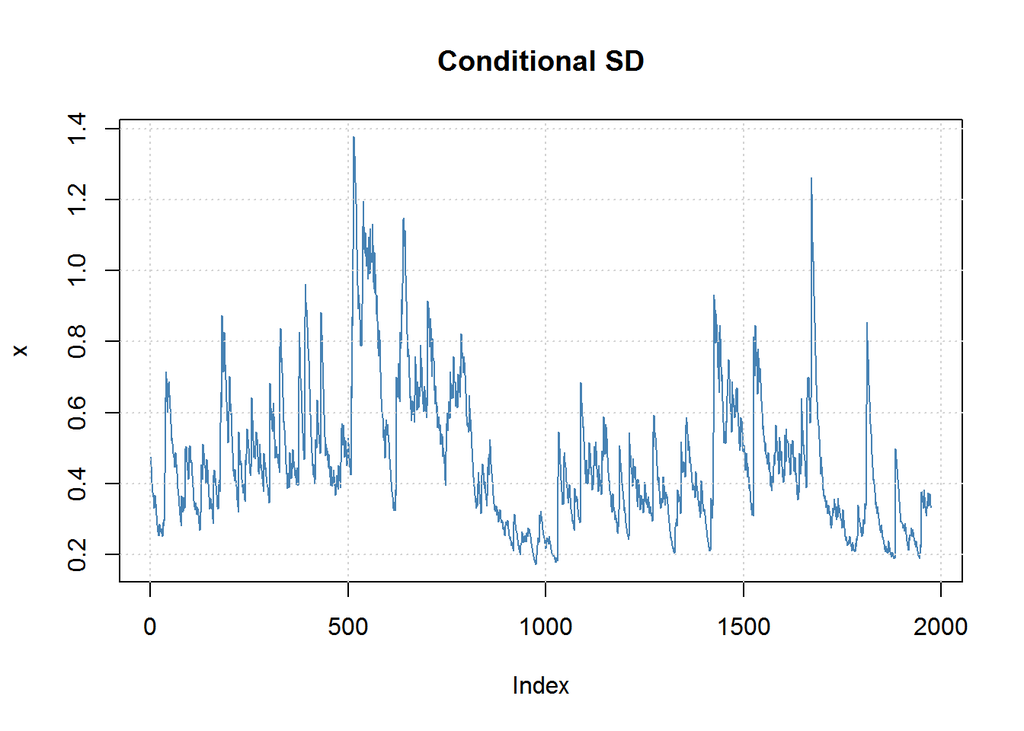

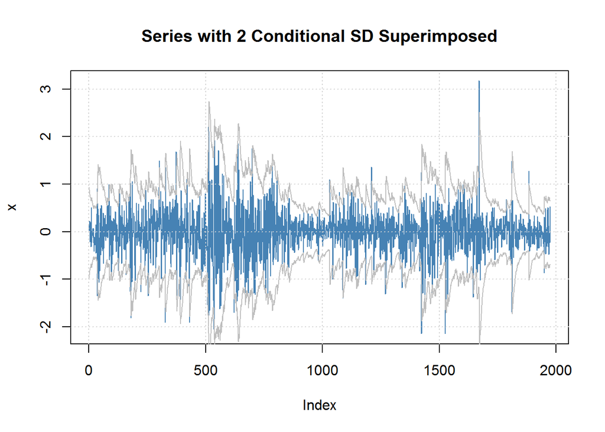

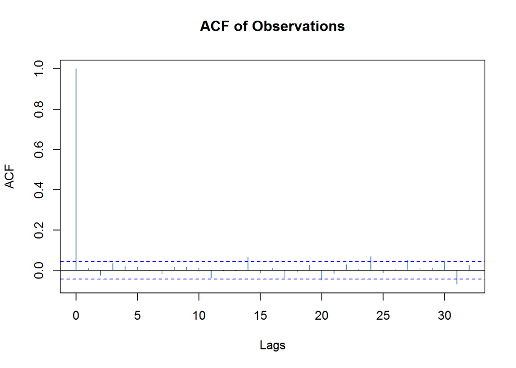

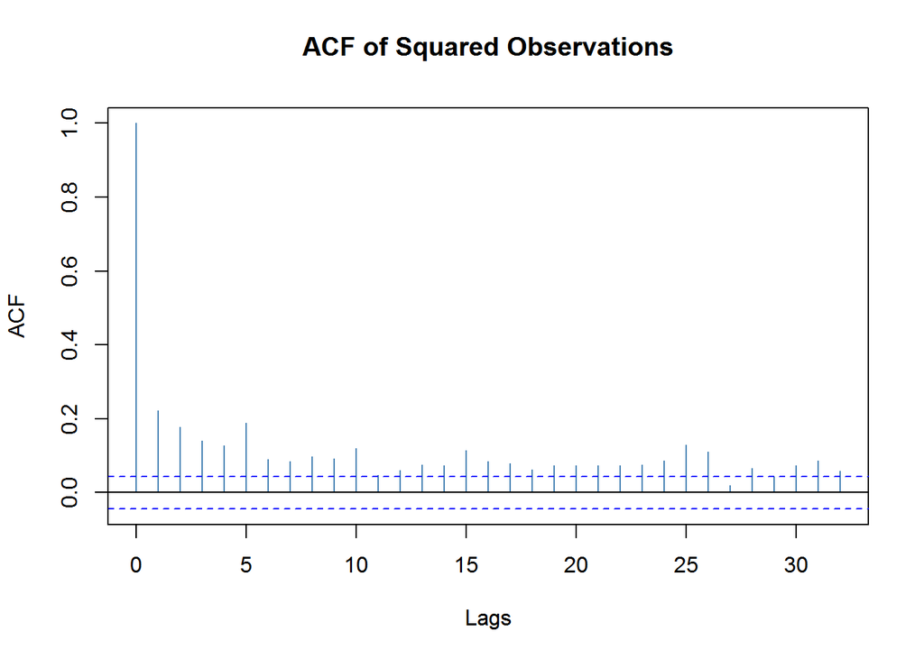

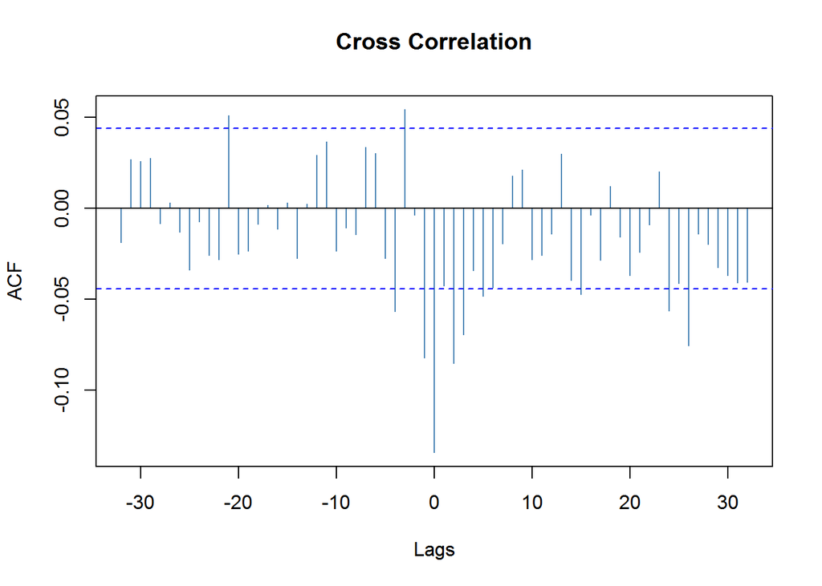

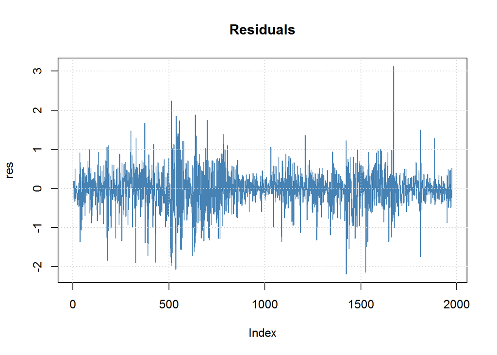

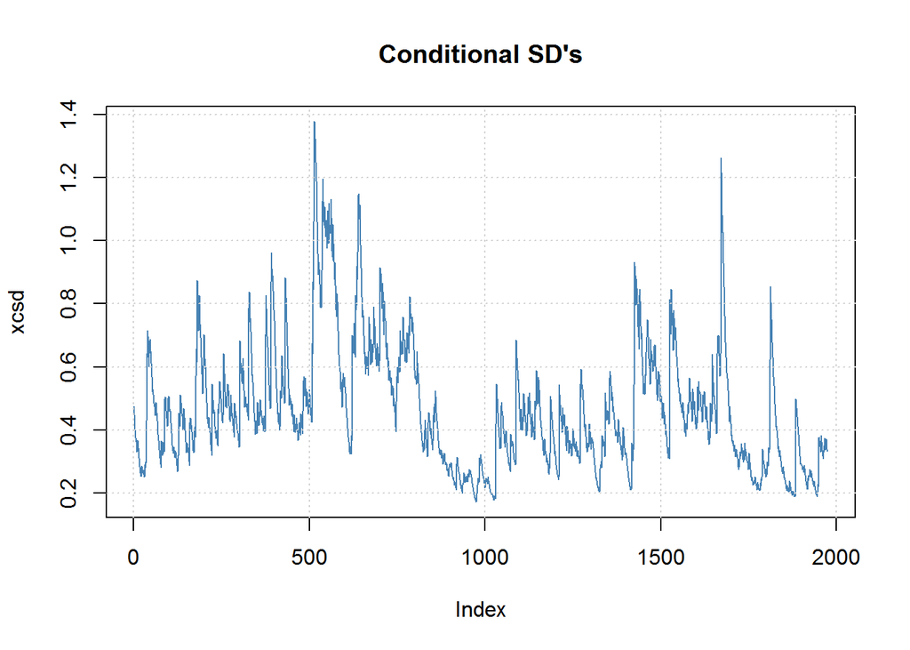

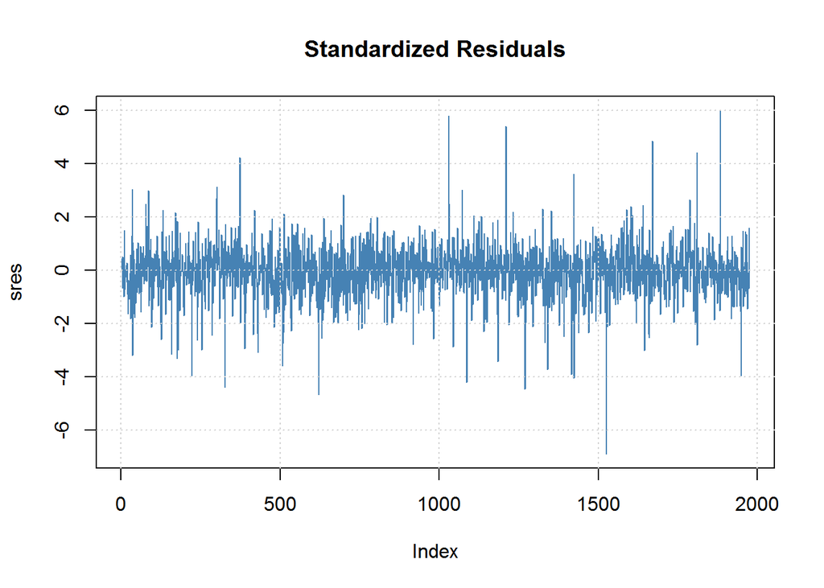

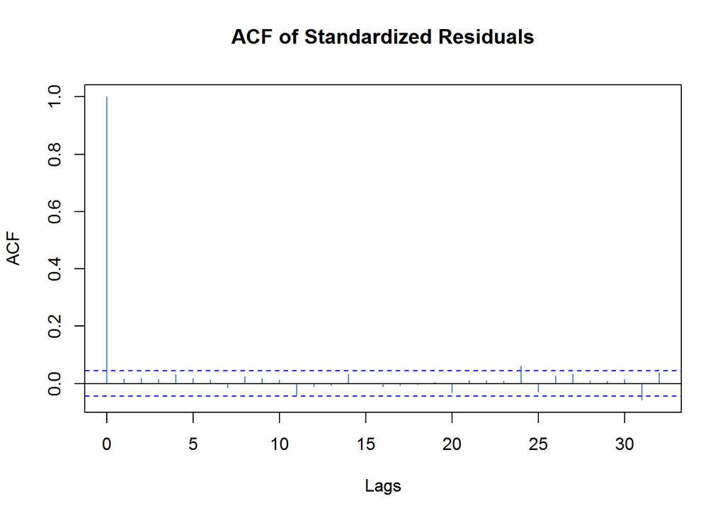

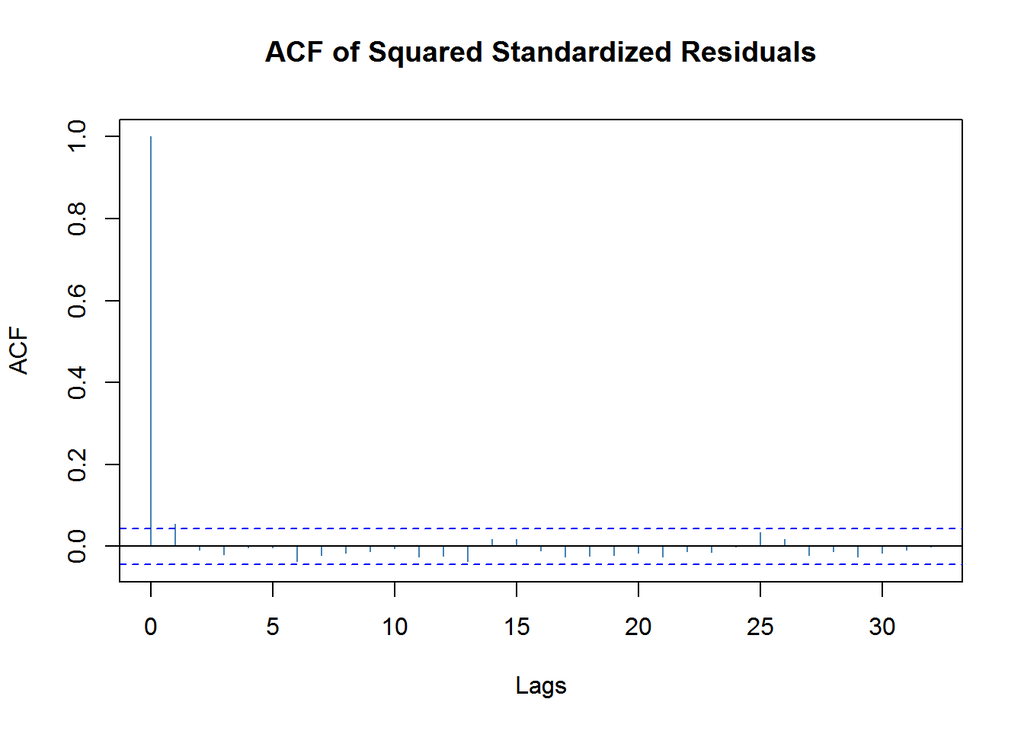

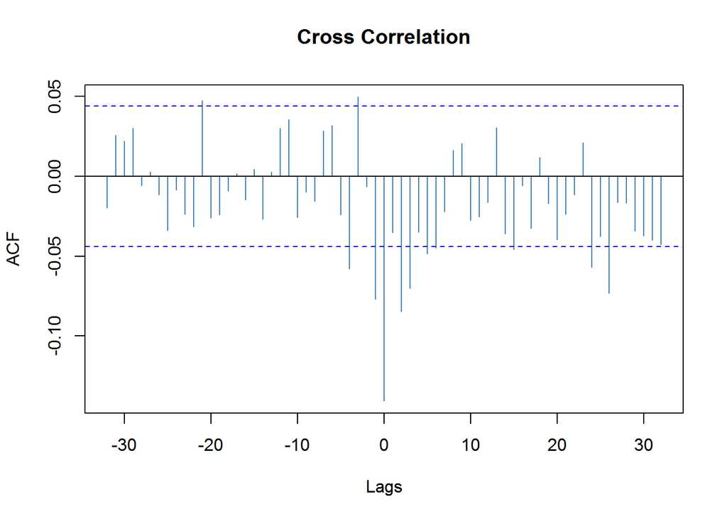

[1 more figures not shown]

```r
plot(fit,which="all")
```

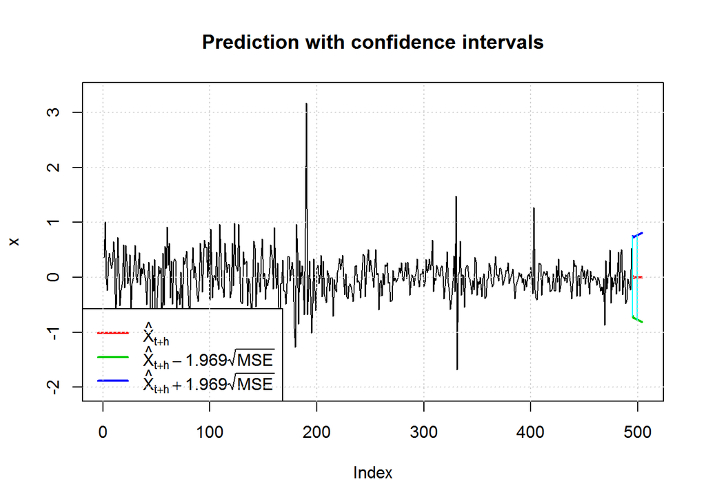

```r
pred <- predict(fit,plot=T)
```

For the sequencing probabilities, let us try to fit a decision tree on 5 lag variables with the original time series being the dependent variable.

As I am interested in just the sign of the sequences and not the magnitude, I will convert the series to just represent the signs (+ve,-ve or 0) for the numbers.

```r
seqDS <- data.frame(original_ts=ts,
                    lag_1=c(-99999,lag(ts,1)[1:length(ts)-1]),
                    lag_2=c(-9999,-9999,lag(ts,2)[1:(length(ts)-2)]),
                    lag_3=c(-9999,-9999,-9999,lag(ts,3)[1:(length(ts)-3)]),
                    lag_4=c(-9999,-9999,-9999,-9999,lag(ts,4)[1:(length(ts)-4)]),
                    lag_5=c(-9999,-9999,-9999,-9999,-9999,lag(ts,5)[1:(length(ts)-5)]))
```

```r
head(seqDS,10)
```

```
##    original_ts  lag_1 lag_2 lag_3 lag_4 lag_5
## 1           -7 -99999 -9999 -9999 -9999 -9999
## 2            1     -7 -9999 -9999 -9999 -9999
## 3            6      1    -7 -9999 -9999 -9999
## 4           -4      6     1    -7 -9999 -9999
## 5           -2     -4     6     1    -7 -9999
## 6            0     -2    -4     6     1    -7
## 7            5      0    -2    -4     6     1
## 8            0      5     0    -2    -4     6
## 9           -3      0     5     0    -2    -4
## 10           3     -3     0     5     0    -2
```

```r
dim(seqDS)
```

```
## [1] 526116      6
```

```r
c1 <- ifelse(seqDS$original_ts==0,0,ifelse(seqDS$original_ts>0,"+ve","-ve"))
c2 <- ifelse(seqDS$lag_1==0,"0",ifelse(seqDS$lag_1>0,"+ve","-ve"))
c3 <- ifelse(seqDS$lag_2==0,"0",ifelse(seqDS$lag_2>0,"+ve","-ve"))
c4 <- ifelse(seqDS$lag_3==0,"0",ifelse(seqDS$lag_3>0,"+ve","-ve"))
c5 <- ifelse(seqDS$lag_4==0,"0",ifelse(seqDS$lag_4>0,"+ve","-ve"))
c6 <- ifelse(seqDS$lag_5==0,"0",ifelse(seqDS$lag_5>0,"+ve","-ve"))

seq <- data.frame(cbind(c1,c2,c3,c4,c5,c6))
head(seq)
```

```
##    c1  c2  c3  c4  c5  c6
## 1 -ve -ve -ve -ve -ve -ve
## 2 +ve -ve -ve -ve -ve -ve
## 3 +ve +ve -ve -ve -ve -ve
## 4 -ve +ve +ve -ve -ve -ve
## 5 -ve -ve +ve +ve -ve -ve
## 6   0 -ve -ve +ve +ve -ve
```

Fitting a decision tree onto this data

```r
tree <- rpart(c1~.,data=seq[-c(1:5),],control=rpart.control(minsplit=2, minbucket=1,cp=0.0001))
```

Plotting the decision rules from the tree

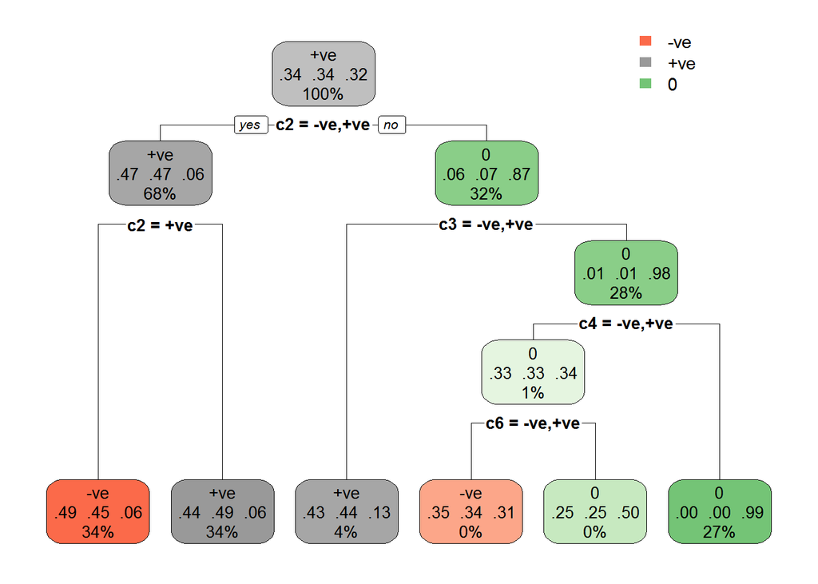

```r
rpart.plot(tree)
```

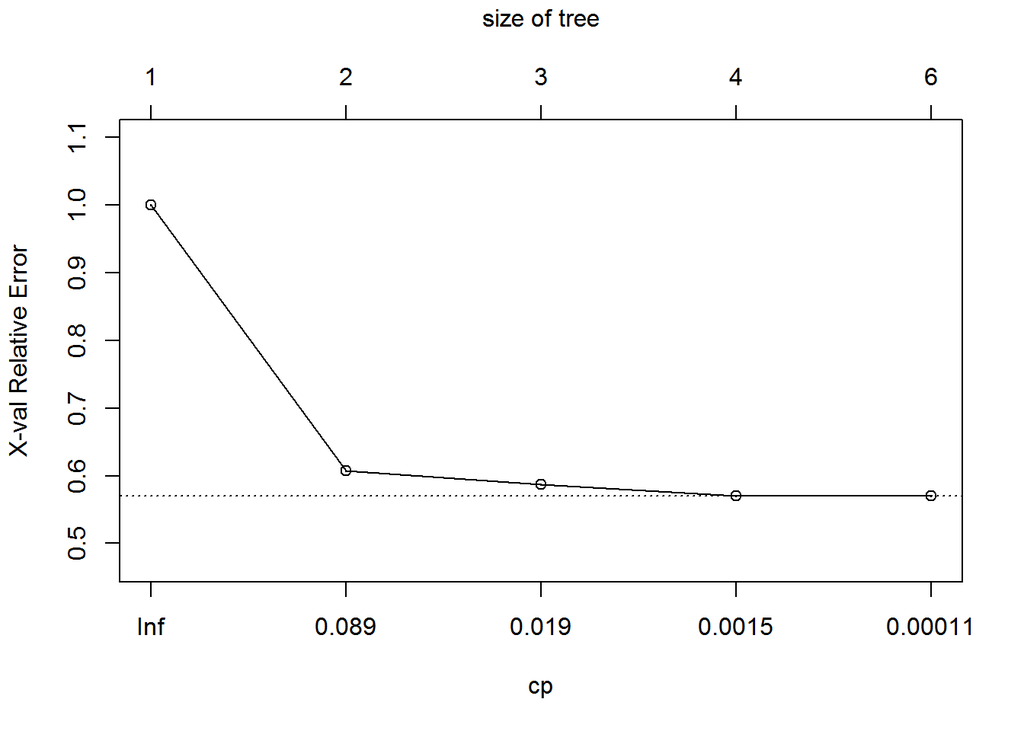

```r
plotcp(tree)
```

The decision tree doesn’t seem to be overfitting the data, so I am content with the sequencing probabilities identified above.

**Business Analysis and Creativity**

**Promo to Subscription prediction model**

This model could be built upon historical data regarding previous marketing campaigns to identify customers’ features/ characteristics who are more likey to subcribe.

External data sources:

- *Social Media Data*: Data regarding social media activity, marital status,educational background, brand consciousness etc. can be obtained from social media aggregators. This data can be really useful in segmenting the customers according to these features and predict the likelihood to subscribe based on the historical data.
- *Occupational Data*: Data regarding what the customers do for a living could potentially determine the economic status of consumers. This sort of data can be obtained from websites like Linkedin, Glassdoor etc.
- *Location Data*:Geo Location data about these customers can be utilized in order to identify local retail wine stores and brands which could be our potential competitors.

Some other measures that could be taken in order to make the campagn more effective:

- *Loyality points*: Loyality points can be provided to customers for each purchase. These loyality points could then be redeemed by the customers for discounts on subsequent purchases.
- *Customer Quizzes*: Customer wine taste can be identified based on personality quizzes.
- *Free delivery over a certain amount of order*: The delivery package can also include sampler wines to try. If the customers like it, then they can add it to their preference list in their profiles.